# Webinar for Census Bureau - Using Tidycensus in R

Corey Sparks, PhD

13 April, 2022

## Structure of webinar

1. About me
2. Using `tidycensus` to get data on places
3. Using `tidycensus` and `tmap` to produce maps
4. Using the `tidycensus` package to get microdata on people

### About Me

I am an associate professor at the University of Texas at San Antonio in the [UTSA Department of Demography](https://hcap.utsa.edu/demography/) and have been there since 2006.

Research interests include data science, Bayesian methods, education demography and health disparities.

You can find me on [Twitter](https://twitter.com/CoreySparks1) and [Github](https://github.com/coreysparks) and my email.

## Using the tidycensus package - Setup

You need to have current versions of [R](https://cran.r-project.org) and preferably [Rstudio](https://www.rstudio.com/products/rstudio/download/) installed.

They tidycensus is a package for the R statistical programming language and is related to the [`tidyverse`](https://www.tidyverse.org/), and was written and maintained by [Dr. Kyle Walker](http://personal.tcu.edu/kylewalker/) at Texas Christian University.

It allows you to dynamically download and map data from the decennial Census and ACS for any level of [Census geography](https://www.census.gov/geo/reference/webatlas/), except blocks!

If you want data on places, this is the easiest way to get it.

To get `tidycensus`, run: `install.packages("tidycensus", dep=T)` in your R session.

### Census table names

The Census publishes data for places in *summary tables*. These follow a pattern for their names, you can find a description of this [here](https://www.census.gov/programs-surveys/acs/guidance/which-data-tool/table-ids-explained.html). The biggest problem with finding data from the Census is knowing the table name you want.

You can find table names for the ACS [here](https://www.census.gov/data/developers/data-sets/acs-5year.html)

### What kind of table do you want?

There are several types of tables the Census publishes.

The [Detailed tables](https://api.census.gov/data/2016/acs/acs5/variables.html) are very detailed summaries of the data for places, in the 2015 data there were more than 64,000 tables published. These can be a little overwhelming to use, but we’ll see an example below

[Subject tables](https://api.census.gov/data/2016/acs/acs5/subject.html) take some of the detailed tables and compute summaries of them around certain demographic, social or economic subjects. Basically this is one way to get more data related to a subject without having to know all of the individual detail tables you need.

[Data Profile tables](https://api.census.gov/data/2016/acs/acs5/profile.html) contain broad social, economic, housing, and demographic information. The data are presented as both counts and percentages. There are over 2,400 variables in this dataset. These are very useful summaries and what I personally rely on for most of my data extracts.

### Get a Census developer API Key!

Obtain one at http://api.census.gov/data/key_signup.html

### Save your API key to your working directory in your R session

I recommend you install your API key in your Rprofile, just so you don’t have to keep pasting it into your code. To do this, type

```
tidycensus::census_api_key(key =  "yourkeyhere", install =
T)
```

one time to install your key for use in `tidycensus`.

### Look at available ACS variables

As I mentioned above, finding the right table can be a challenge, especially for new data users. `tidycensus` has the `load_variables()` function that will load all of the available tables for a specific table type.

For example, if we are interested in variables from the ACS [data profile](https://www.census.gov/acs/www/data/data-tables-and-tools/data-profiles/2016/) tables, we can load all available variables then use R to search for what we need.

One of the best ways to search is to use [`grep()`](https://en.wikipedia.org/wiki/Grep), which is a tool for searching for patterns within text, and is *SUPER USEFUL!*

Here I load the 2019 5-year ACS variables from the data profile tables, and search for a keyword

```r
v19_Profile <- load_variables(year = 2019 ,
                              dataset = "acs5/profile",
                              cache = TRUE) #data profile tables
```

#### Open the data for examination

```r
View(v19_Profile)
```

### Search for variables by keywords in the label

```r
v19_Profile[grep(x = v19_Profile$label, "Median household"),
            c("name", "label")]
```

| name | label |
| --- | --- |
| DP03_0062 | Estimate!!INCOME AND BENEFITS (IN 2019 INFLATION-ADJUSTED DOLLARS)!!Total households!!Median household income (dollars) |
| DP03_0062P | Percent!!INCOME AND BENEFITS (IN 2019 INFLATION-ADJUSTED DOLLARS)!!Total households!!Median household income (dollars) |

To view the detailed tables, you change the `dataset` argument to `acs5`:

```r
v19_detailed <- load_variables(year = 2019 ,
                               dataset = "acs5")# detail tables
```

### Search for variables by keywords in the label

```r
v19_detailed[grep(x = v19_detailed$label, "Median household"),
            c("name", "label")]
```

### Search for variables by keywords in the label

| name | label |
| --- | --- |
| B19013_001 | Estimate!!Median household income in the past 12 months (in 2019 inflation-adjusted dollars) |
| B19013A_001 | Estimate!!Median household income in the past 12 months (in 2019 inflation-adjusted dollars) |
| B19013B_001 | Estimate!!Median household income in the past 12 months (in 2019 inflation-adjusted dollars) |
| B19013C_001 | Estimate!!Median household income in the past 12 months (in 2019 inflation-adjusted dollars) |
| B19013D_001 | Estimate!!Median household income in the past 12 months (in 2019 inflation-adjusted dollars) |
| B19013E_001 | Estimate!!Median household income in the past 12 months (in 2019 inflation-adjusted dollars) |
| B19013F_001 | Estimate!!Median household income in the past 12 months (in 2019 inflation-adjusted dollars) |
| B19013G_001 | Estimate!!Median household income in the past 12 months (in 2019 inflation-adjusted dollars) |
| B19013H_001 | Estimate!!Median household income in the past 12 months (in 2019 inflation-adjusted dollars) |
| B19013I_001 | Estimate!!Median household income in the past 12 months (in 2019 inflation-adjusted dollars) |
| B19049_001 | Estimate!!Median household income in the past 12 months (in 2019 inflation-adjusted dollars) –!!Total: |
| B19049_002 | Estimate!!Median household income in the past 12 months (in 2019 inflation-adjusted dollars) –!!Total:!!Householder under 25 years |
| B19049_003 | Estimate!!Median household income in the past 12 months (in 2019 inflation-adjusted dollars) –!!Total:!!Householder 25 to 44 years |
| B19049_004 | Estimate!!Median household income in the past 12 months (in 2019 inflation-adjusted dollars) –!!Total:!!Householder 45 to 64 years |
| B19049_005 | Estimate!!Median household income in the past 12 months (in 2019 inflation-adjusted dollars) –!!Total:!!Householder 65 years and over |
| B22008_001 | Estimate!!Median household income in the past 12 months (in 2019 inflation-adjusted dollars)–!!Total: |
| B22008_002 | Estimate!!Median household income in the past 12 months (in 2019 inflation-adjusted dollars)–!!Total:!!Household received Food Stamps/SNAP in the past 12 months |
| B22008_003 | Estimate!!Median household income in the past 12 months (in 2019 inflation-adjusted dollars)–!!Total:!!Household did not receive Food Stamps/SNAP in the past 12 months |
| B25099_001 | Estimate!!Median household income –!!Total: |
| B25099_002 | Estimate!!Median household income –!!Total:!!Median household income for units with a mortgage |
| B25099_003 | Estimate!!Median household income –!!Total:!!Median household income for units without a mortgage |
| B25119_001 | Estimate!!Median household income in the past 12 months (in 2019 inflation-adjusted dollars) –!!Total: |
| B25119_002 | Estimate!!Median household income in the past 12 months (in 2019 inflation-adjusted dollars) –!!Total:!!Owner occupied (dollars) |
| B25119_003 | Estimate!!Median household income in the past 12 months (in 2019 inflation-adjusted dollars) –!!Total:!!Renter occupied (dollars) |
| B29004_001 | Estimate!!Median household income in the past 12 months (in 2019 inflation-adjusted dollars) |

## Extract from ACS summary file data profile variables from 2019 for Bexar County, TX Census Tracts

Here is a real example:

The data profile tables are very useful because they contain lots of pre-calculated variables.

Using `output="wide"` will put each variable in a column of the data set, with each row being a census tract. This is useful if you’re requesting multiple variables.

```r
sa_acs<-get_acs(geography = "tract", #level of geography requested
                state="TX", #can use state FIPS codes as well e.g. 48
                county = "029", #County FIPS codes are safer
                year = 2019,
                variables=c( "DP03_0062E") ,
                geometry = T, #merge estimates to Census geographies
                output = "wide")
head(sa_acs)
```

Here I rename variables and filter missing cases

```r
sa_acs<-sa_acs%>%
  # mutate( medhhinc=DP03_0062E,
  #         medhhinc_moe = DP03_0062M) %>%
  select(GEOID, NAME, medhhinc=DP03_0062E, medhhinc_moe= DP03_0062M )%>%
  filter(complete.cases(medhhinc))

#take a peek at the first few lines of data
head(sa_acs)
```

|  | GEOID | NAME | medhhinc | medhhinc_moe | geometry |
| --- | --- | --- | --- | --- | --- |
| 1 | 48029190601 | Census Tract 1906.01, Bexar County, Texas | 46818 | 14436 |  |
| 2 | 48029181100 | Census Tract 1811, Bexar County, Texas | 64930 | 6521 |  |
| 3 | 48029140700 | Census Tract 1407, Bexar County, Texas | 36222 | 6656 |  |
| 4 | 48029180602 | Census Tract 1806.02, Bexar County, Texas | 38389 | 7038 |  |
| 5 | 48029140800 | Census Tract 1408, Bexar County, Texas | 43299 | 3656 |  |
| 6 | 48029170200 | Census Tract 1702, Bexar County, Texas | 25755 | 7141 |  |

### Using `tidycensus` with `tmap` to produce maps

We can immediately map these data as well, because `tidycensus` can get you the geography corresponding to your data.

Here, I use the `dplyr` pipe “`%>%`” to feed the data into `tmap` and map the median household income for each census tract in Bexar County, using a quantile break system.

```
## tmap mode set to plotting
```

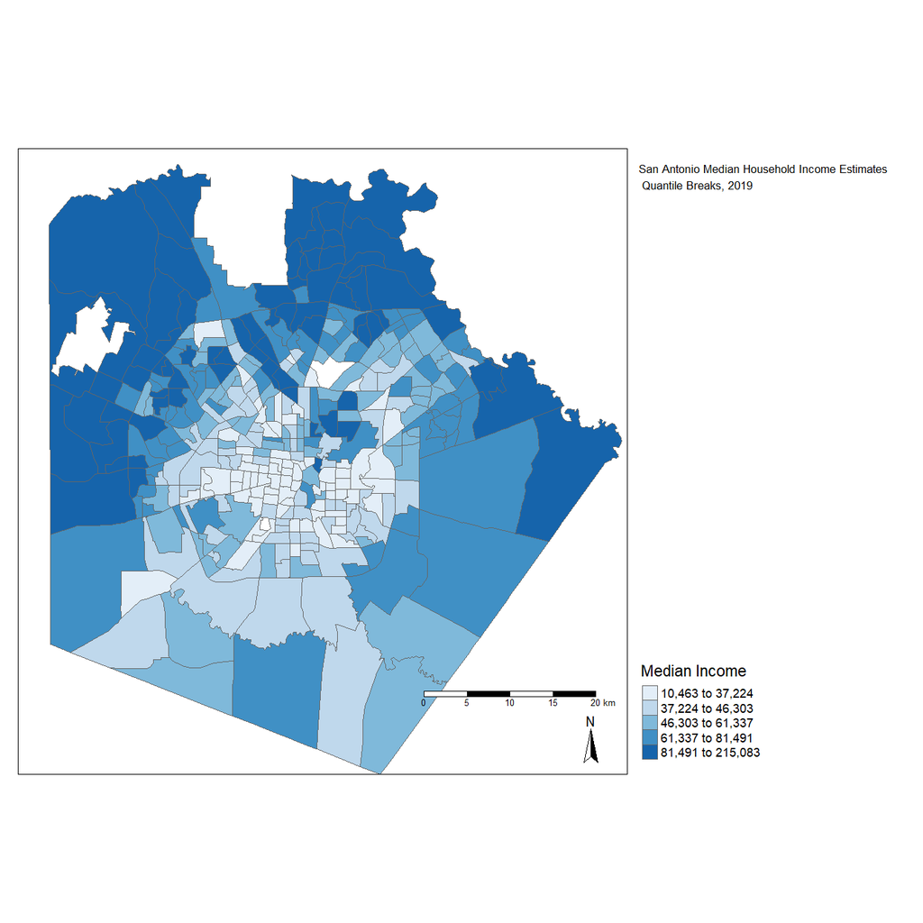

```r
library(tmap) #need to install on your system

sa_acs%>%
  tm_shape()+
  tm_polygons("medhhinc",
              title="Median Income",
              palette="Blues",
              style="quantile", n=5 )+
  tm_format("World",
            title="San Antonio Median Household Income Estimates\n Quantile Breaks, 2019",
            legend.outside=T)+
  tm_scale_bar()+
  tm_compass()
```

```r
tmap_save(filename = "SA_Income.png")
```

```
## Map saved to C:\Users\ozd504\Github\r_courses\census_webinar\SA_Income.png
```

```
## Resolution: 2072.53 by 2127.835 pixels
```

```
## Size: 6.908432 by 7.092782 inches (300 dpi)
```

### Interactive maps with `tmap`

```r
tmap_mode("view")
```

```
## tmap mode set to interactive viewing
```

```r
sa_acs%>%
  tm_shape()+
  tm_polygons("medhhinc",
              alpha = .75,
              title="Median Income",
              palette="Blues",
              style="quantile", n=5 )
```

[interactive chart not shown]

## Saving data to spatial data files

#### Write data out to geopackage or other format

You may need to create or modify some data in R and then use it in the desktop GIS (QGIS/ArcGIS), we can write any data from R into a variety of data formats using the `sf::st_write()` function.

```r
#change the directory for your computer
sf::st_write(sa_acs,
             dsn="sa_tr.gpkg",
             layer="sa_MedIncome_19",
             driver="GPKG") ## Save as geopackage format
```

### Using `tidycensus` to access public use microdata

The `pums_variables` dataframe within the `tidycensus` package contains all the PUMS variables by year, survey and level (person or household)

```r
person_2019 <- pums_variables%>%
  filter(year == 2019,
         survey == "acs5",
         level == "person")
```

| survey | year | var_code | var_label | data_type | level | val_min | val_max | val_label | recode | val_length | val_na |
| --- | --- | --- | --- | --- | --- | --- | --- | --- | --- | --- | --- |
| acs5 | 2019 | SPORDER | Person number | num | person | 01 | 20 | Person number | FALSE | NA | NA |
| acs5 | 2019 | PWGTP | Person weight | num | person | 1 | 9999 | Integer weight of person | FALSE | NA | NA |
| acs5 | 2019 | AGEP | Age | num | person | 0 | 0 | Under 1 year | FALSE | NA | NA |
| acs5 | 2019 | AGEP | Age | num | person | 1 | 99 | 1 to 99 years (Top-coded) | FALSE | NA | NA |
| acs5 | 2019 | CIT | Citizenship status | chr | person | 1 | 1 | Born in the U.S. | TRUE | 1 | NA |
| acs5 | 2019 | CIT | Citizenship status | chr | person | 2 | 2 | Born in Puerto Rico, Guam, the U.S. Virgin Islands, or the Northern Marianas | TRUE | 1 | NA |
| acs5 | 2019 | CIT | Citizenship status | chr | person | 3 | 3 | Born abroad of American parent(s) | TRUE | 1 | NA |
| acs5 | 2019 | CIT | Citizenship status | chr | person | 4 | 4 | U.S. citizen by naturalization | TRUE | 1 | NA |
| acs5 | 2019 | CIT | Citizenship status | chr | person | 5 | 5 | Not a citizen of the U.S. | TRUE | 1 | NA |
| acs5 | 2019 | CITWP | Year of naturalization write-in | num | person | bbbb | bbbb | Not eligible - not naturalized | FALSE | NA | NA |
| acs5 | 2019 | CITWP | Year of naturalization write-in | num | person | 1944 | 1944 | 1944 or earlier (Bottom-coded) | FALSE | NA | NA |
| acs5 | 2019 | CITWP | Year of naturalization write-in | num | person | 1945 | 1945 | 1945 - 1947 | FALSE | NA | NA |
| acs5 | 2019 | CITWP | Year of naturalization write-in | num | person | 1948 | 1948 | 1948 - 1949 | FALSE | NA | NA |
| acs5 | 2019 | CITWP | Year of naturalization write-in | num | person | 1950 | 1950 | 1950 | FALSE | NA | NA |
| acs5 | 2019 | CITWP | Year of naturalization write-in | num | person | 1951 | 1951 | 1951 | FALSE | NA | NA |
| acs5 | 2019 | CITWP | Year of naturalization write-in | num | person | 1952 | 1952 | 1952 | FALSE | NA | NA |
| acs5 | 2019 | CITWP | Year of naturalization write-in | num | person | 1953 | 1953 | 1953 | FALSE | NA | NA |
| acs5 | 2019 | CITWP | Year of naturalization write-in | num | person | 1954 | 1954 | 1954 | FALSE | NA | NA |
| acs5 | 2019 | CITWP | Year of naturalization write-in | num | person | 1955 | 1955 | 1955 | FALSE | NA | NA |
| acs5 | 2019 | CITWP | Year of naturalization write-in | num | person | 1956 | 1956 | 1956 | FALSE | NA | NA |

```r
pums_tx <- get_pums(year = 2019,
                 state = c("TX"),  #list of states, FIPS codes also work
                 survey = "acs5", # survey you are wanting
                 variables =c("ST","PUMA", "PWGTP", "AGEP", "SCHL", "SEX", "WAGP", "HISP", "RAC1P", "FOD1P"),
                 recode = T, #adds labels for variables, optional
                 variables_filter = list(AGEP = 18:65) #optional filter for Age in 18:65, optional
                 )
head(pums_tx)
```

| SERIALNO | SPORDER | WGTP | PWGTP | WAGP | AGEP | PUMA | ST | SCHL | SEX | FOD1P | HISP | RAC1P | ST_label | SCHL_label | SEX_label | FOD1P_label | HISP_label | RAC1P_label |
| --- | --- | --- | --- | --- | --- | --- | --- | --- | --- | --- | --- | --- | --- | --- | --- | --- | --- | --- |
| 2015000000016 | 1 | 8 | 8 | 63000 | 42 | 03200 | 48 | 19 | 2 | 1099 | 02 | 8 | Texas/TX | 1 or more years of college credit, no degree | Female | NA | Mexican | Some Other Race alone |
| 2015000000019 | 1 | 15 | 14 | 54000 | 62 | 03000 | 48 | 19 | 1 | 1099 | 01 | 1 | Texas/TX | 1 or more years of college credit, no degree | Male | NA | Not Spanish/Hispanic/Latino | White alone |
| 2015000000019 | 2 | 15 | 17 | 60000 | 64 | 03000 | 48 | 15 | 2 | 1099 | 01 | 1 | Texas/TX | 12th grade - no diploma | Female | NA | Not Spanish/Hispanic/Latino | White alone |
| 2015000000064 | 1 | 28 | 28 | 19000 | 32 | 04627 | 48 | 19 | 2 | 1099 | 01 | 9 | Texas/TX | 1 or more years of college credit, no degree | Female | NA | Not Spanish/Hispanic/Latino | Two or More Races |
| 2015000000064 | 4 | 28 | 38 | 25000 | 34 | 04627 | 48 | 19 | 1 | 1099 | 01 | 2 | Texas/TX | 1 or more years of college credit, no degree | Male | NA | Not Spanish/Hispanic/Latino | Black or African American alone |
| 2015000000083 | 2 | 55 | 69 | 70000 | 45 | 02306 | 48 | 21 | 2 | 3401 | 01 | 1 | Texas/TX | Bachelor's degree | Female | Liberal Arts | Not Spanish/Hispanic/Latino | White alone |

```r
readr::write_csv(pums_tx,
                 file  = "pums_tx_2019.csv")
```